# visual_guessing_r_sc

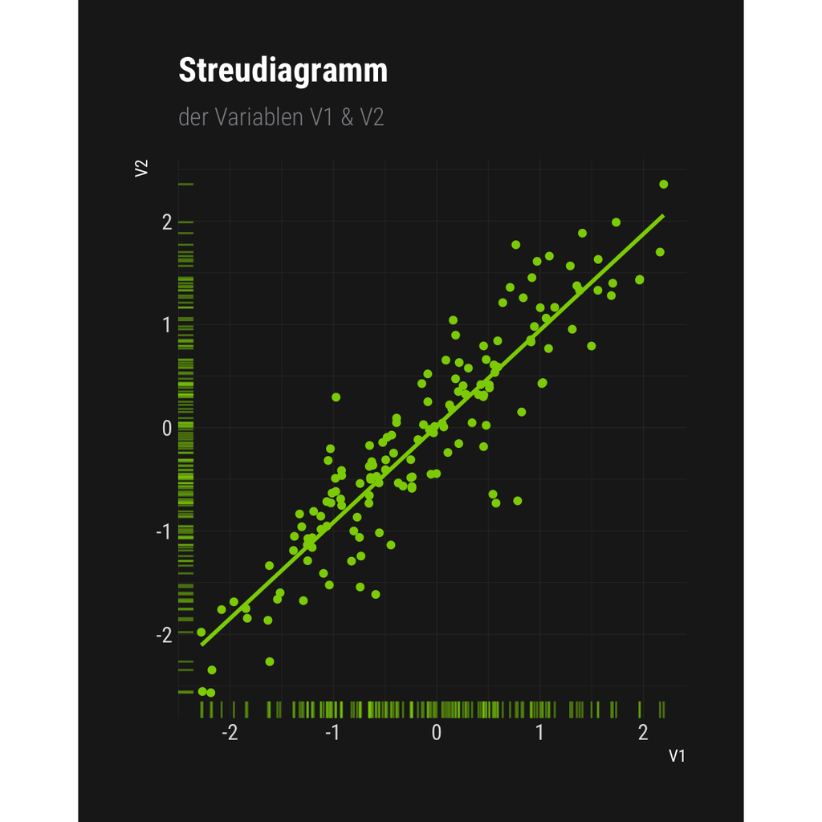

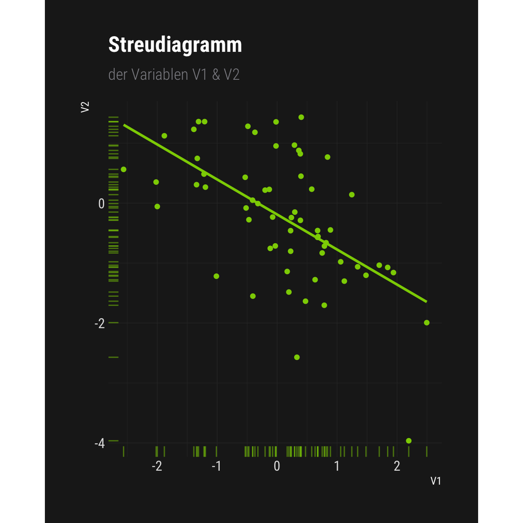

Obige Abbildung zeigt die Assoziation der beiden Variablen V1 und V2. Welches Pearson’s r(V1,V2) passt am besten zu diesen Daten?

-0.93-0.58-0.230.120.470.82

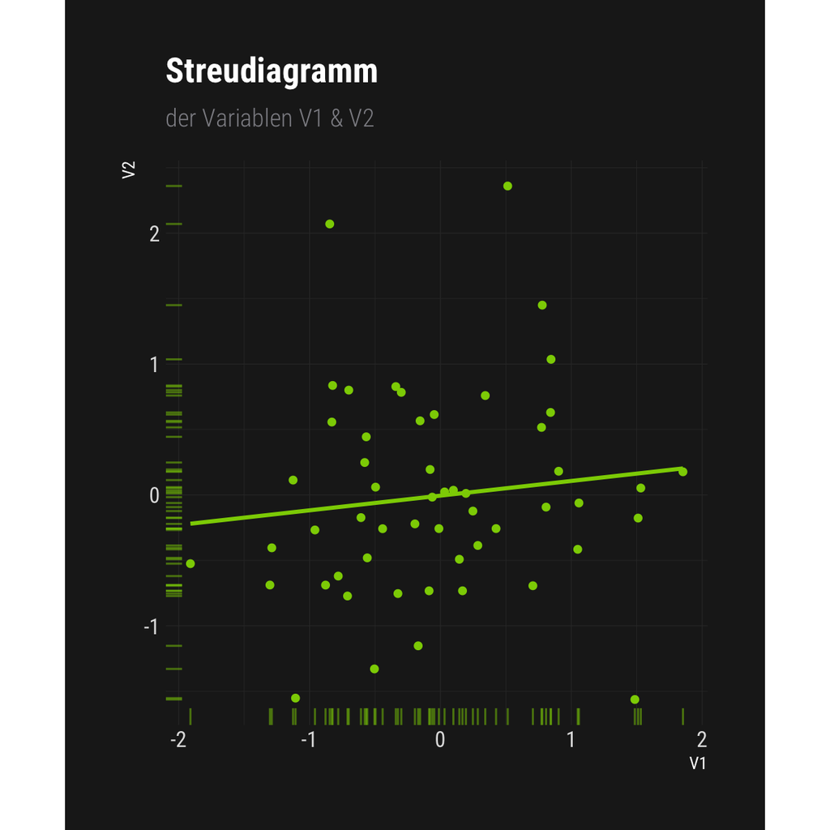

Obige Abbildung zeigt die Assoziation der beiden Variablen V1 und V2. Welches Pearson’s r(V1,V2) passt am besten zu diesen Daten?

-0.93-0.58-0.230.120.470.82

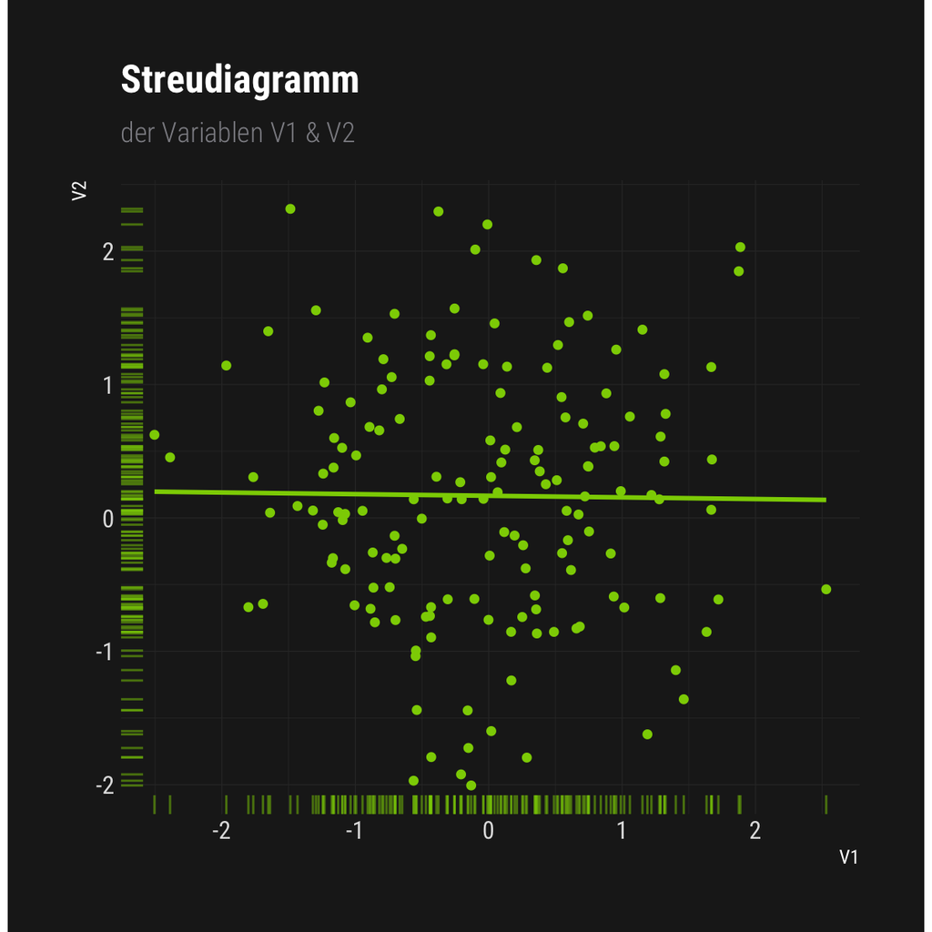

Obige Abbildung zeigt die Assoziation der beiden Variablen V1 und V2. Welches Pearson’s r(V1,V2) passt am besten zu diesen Daten?

-0.71-0.36-0.010.340.69

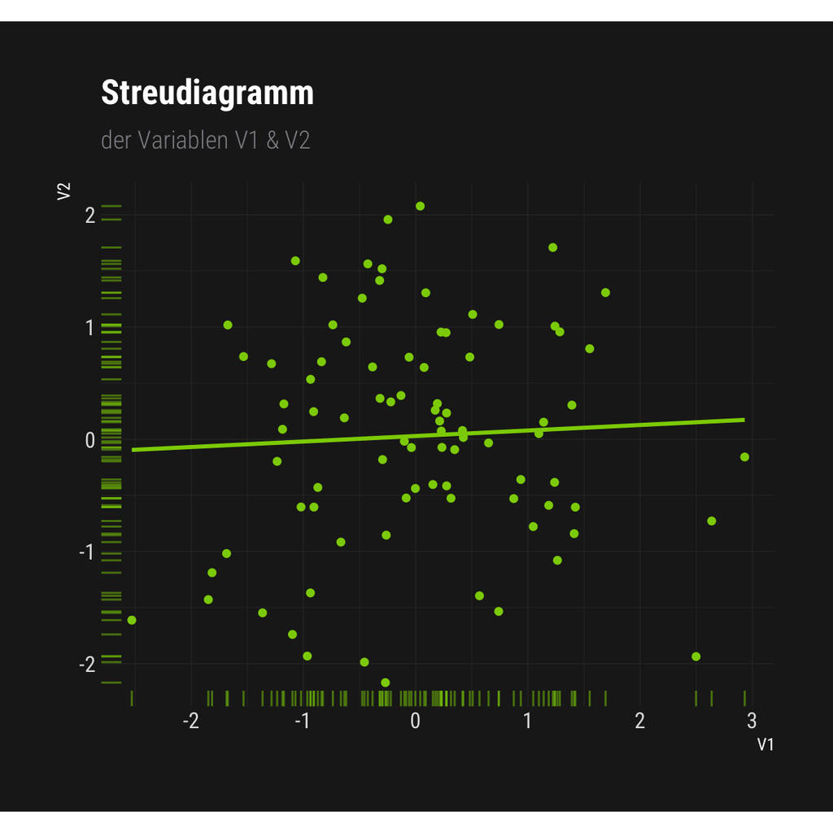

Obige Abbildung zeigt die Assoziation der beiden Variablen V1 und V2. Welches Pearson’s r(V1,V2) passt am besten zu diesen Daten?

-1-0.65-0.30.050.40.75

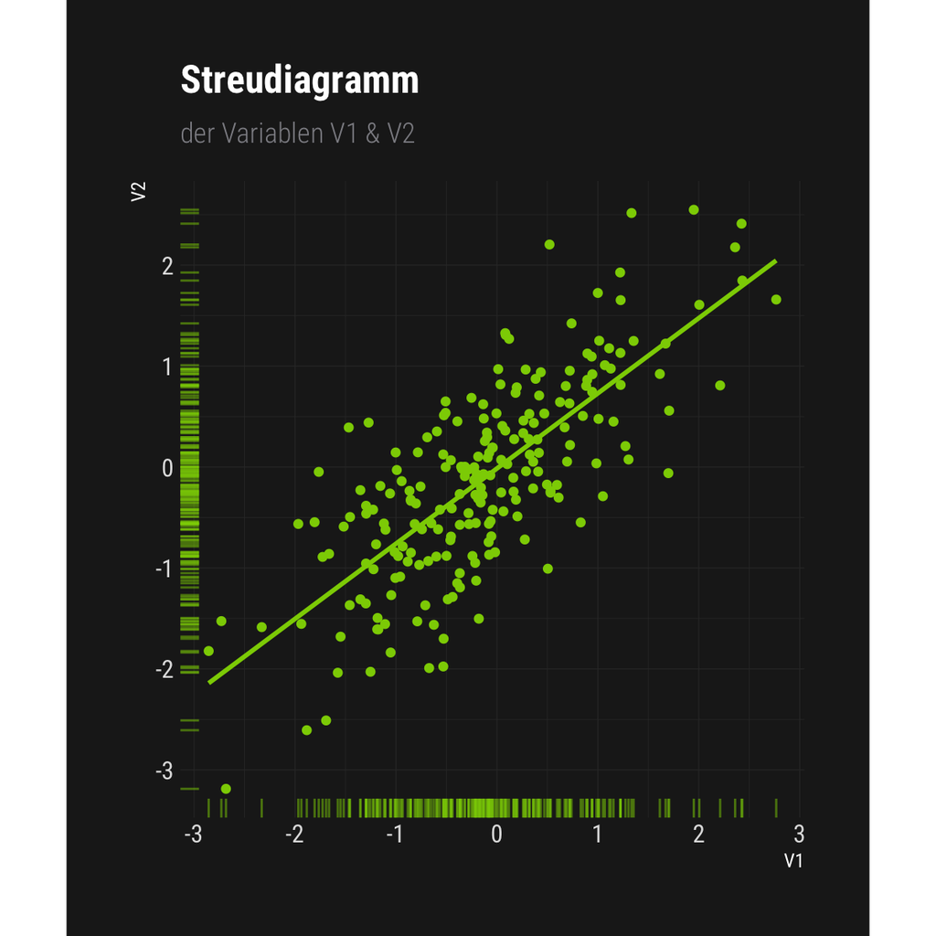

Obige Abbildung zeigt die Assoziation der beiden Variablen V1 und V2. Welches Pearson’s r(V1,V2) passt am besten zu diesen Daten?

-1-0.65-0.30.050.40.75

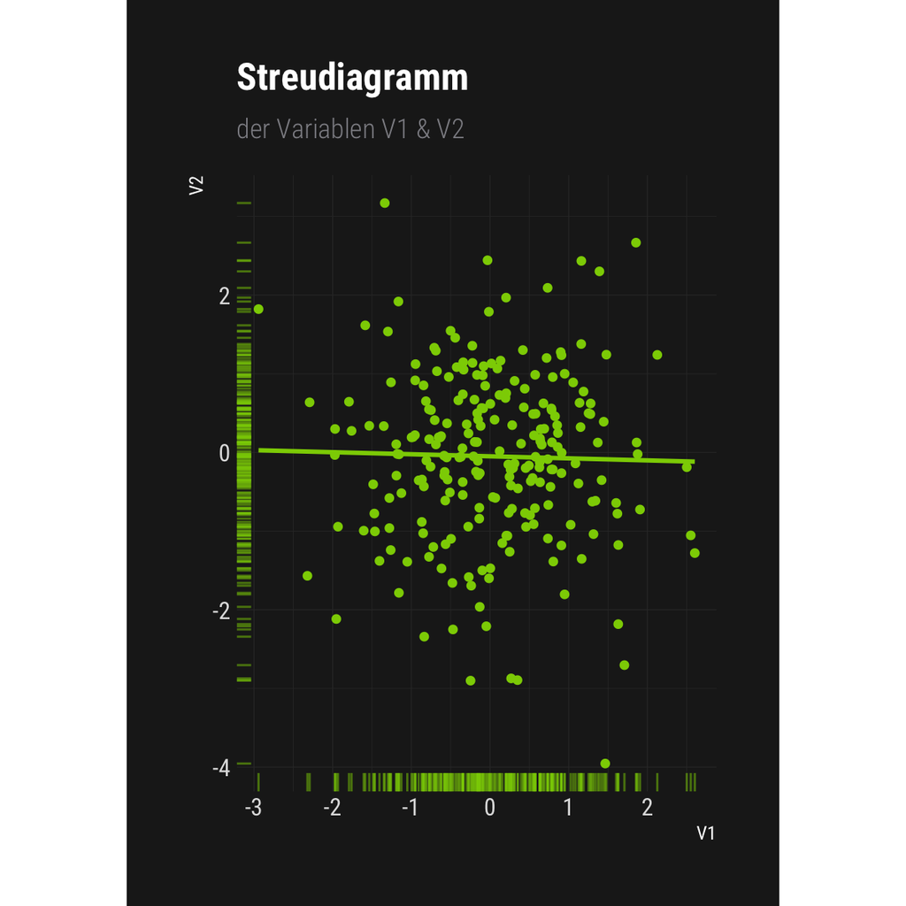

Obige Abbildung zeigt die Assoziation der beiden Variablen V1 und V2. Welches Pearson’s r(V1,V2) passt am besten zu diesen Daten?

-0.72-0.37-0.020.330.68

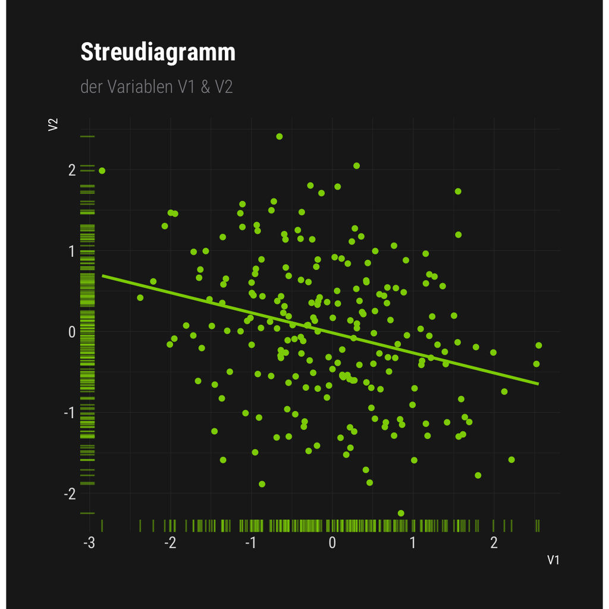

Obige Abbildung zeigt die Assoziation der beiden Variablen V1 und V2. Welches Pearson’s r(V1,V2) passt am besten zu diesen Daten?

-0.98-0.63-0.280.070.420.77

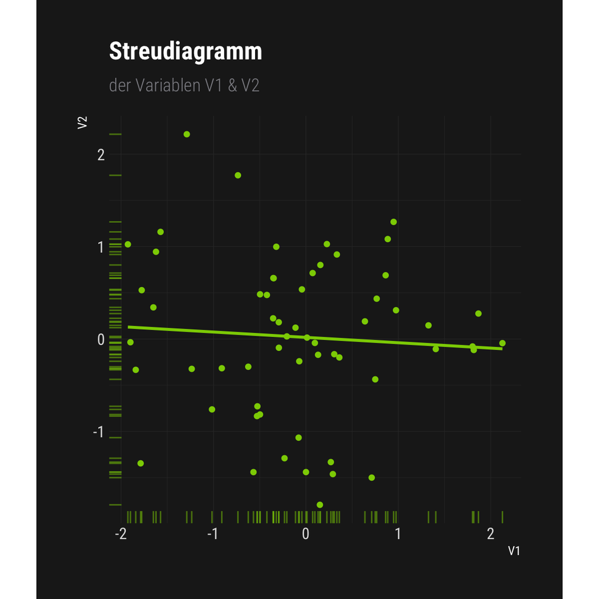

Obige Abbildung zeigt die Assoziation der beiden Variablen V1 und V2. Welches Pearson’s r(V1,V2) passt am besten zu diesen Daten?

-0.77-0.42-0.070.280.630.98

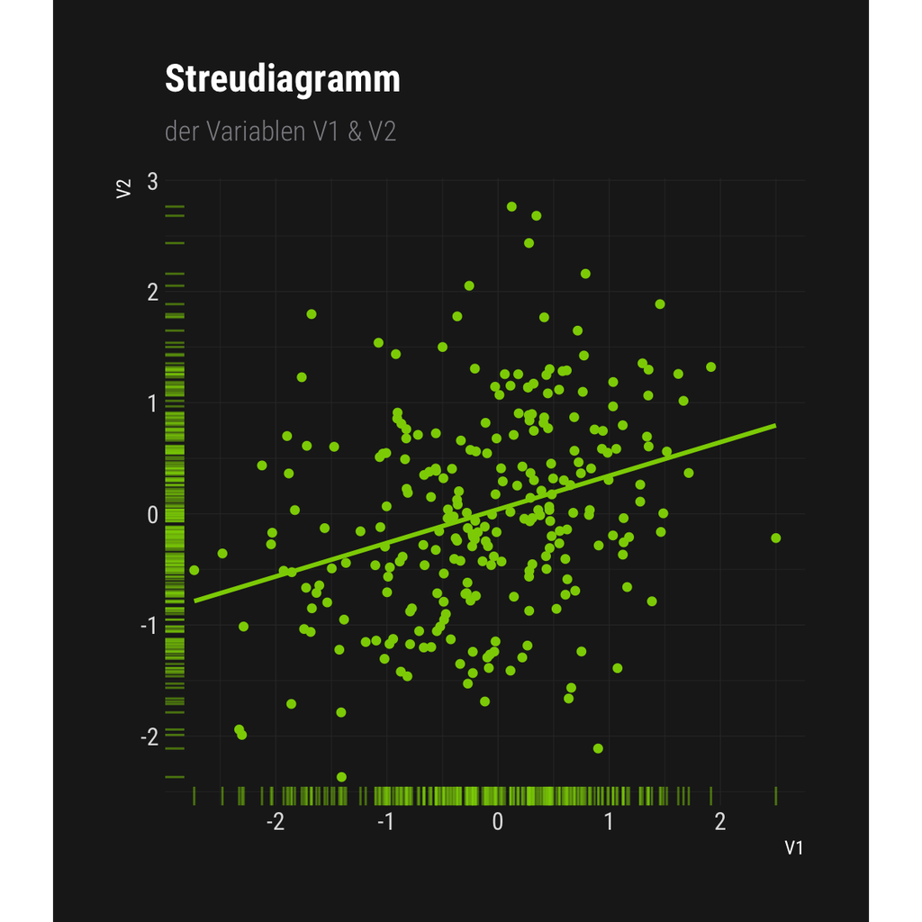

Obige Abbildung zeigt die Assoziation der beiden Variablen V1 und V2. Welches Pearson’s r(V1,V2) passt am besten zu diesen Daten?

-0.74-0.39-0.040.310.66

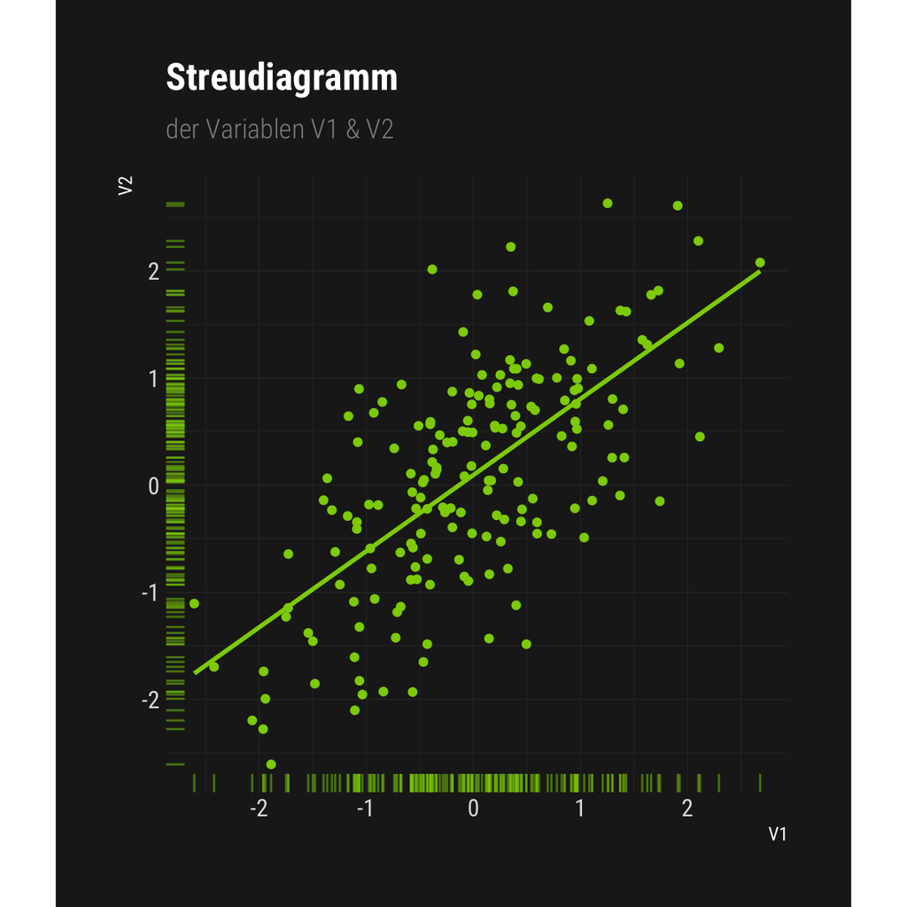

Obige Abbildung zeigt die Assoziation der beiden Variablen V1 und V2. Welches Pearson’s r(V1,V2) passt am besten zu diesen Daten?

-0.74-0.39-0.040.310.66

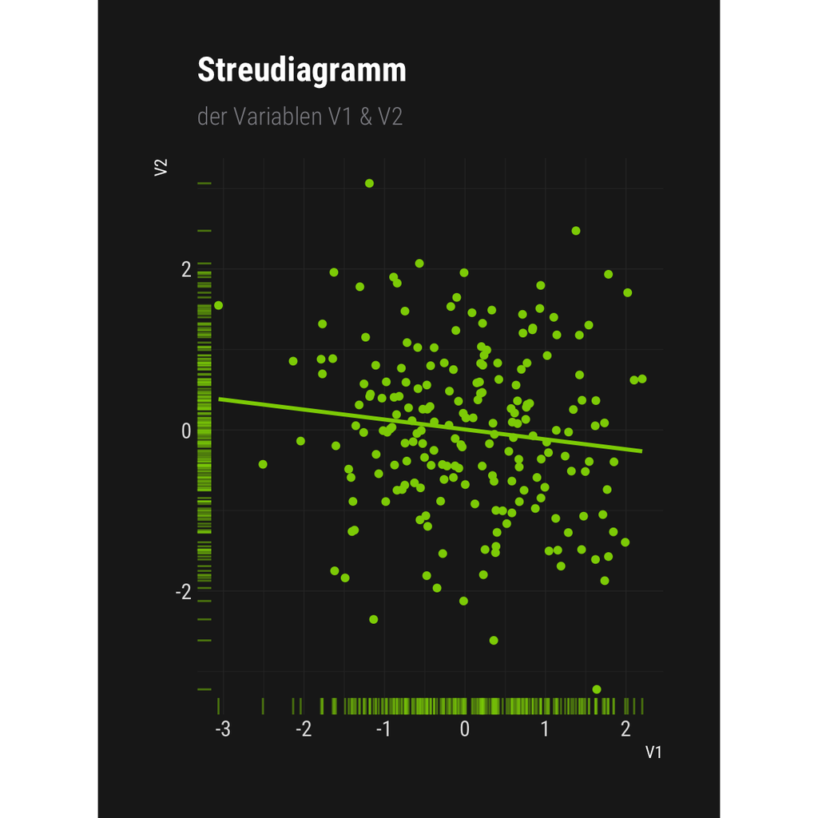

Obige Abbildung zeigt die Assoziation der beiden Variablen V1 und V2. Welches Pearson’s r(V1,V2) passt am besten zu diesen Daten?

-0.82-0.47-0.120.230.580.93

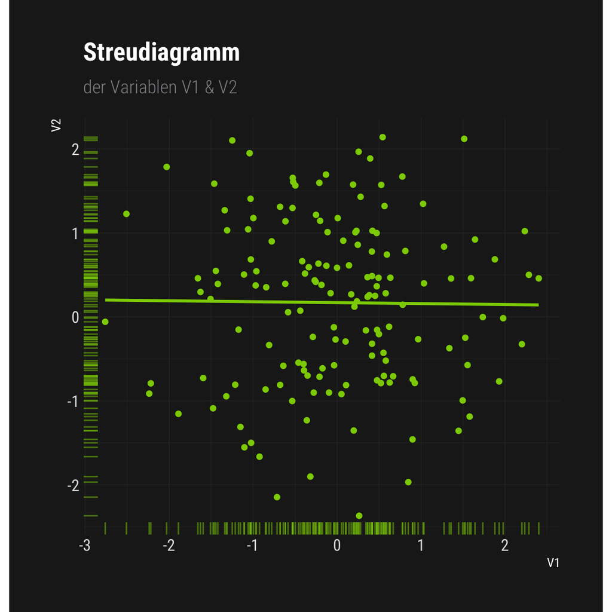

Obige Abbildung zeigt die Assoziation der beiden Variablen V1 und V2. Welches Pearson’s r(V1,V2) passt am besten zu diesen Daten?

-0.71-0.36-0.010.340.69

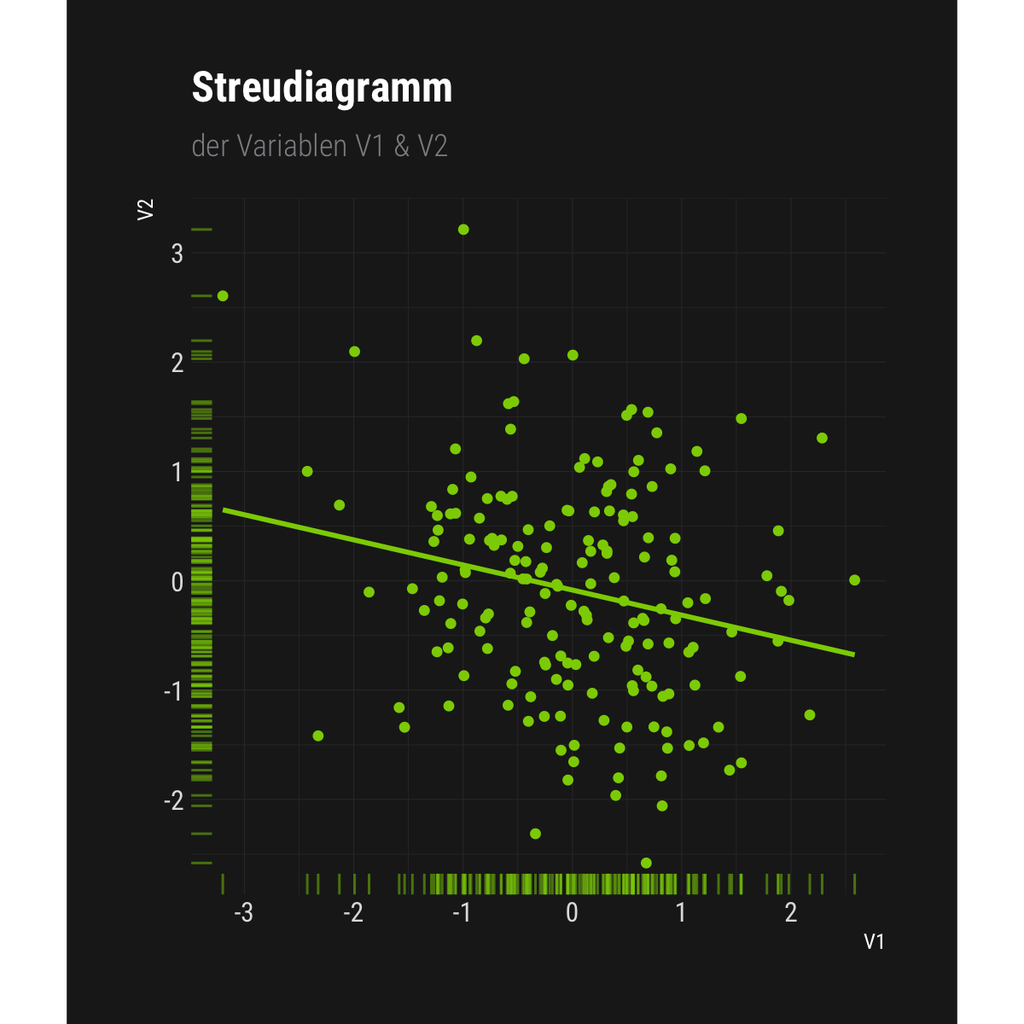

Obige Abbildung zeigt die Assoziation der beiden Variablen V1 und V2. Welches Pearson’s r(V1,V2) passt am besten zu diesen Daten?

-0.92-0.57-0.220.130.480.83

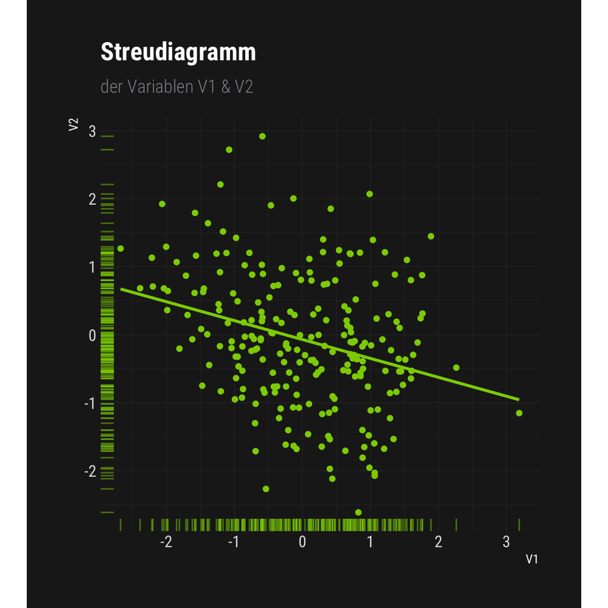

Obige Abbildung zeigt die Assoziation der beiden Variablen V1 und V2. Welches Pearson’s r(V1,V2) passt am besten zu diesen Daten?

-0.99-0.64-0.290.060.410.76

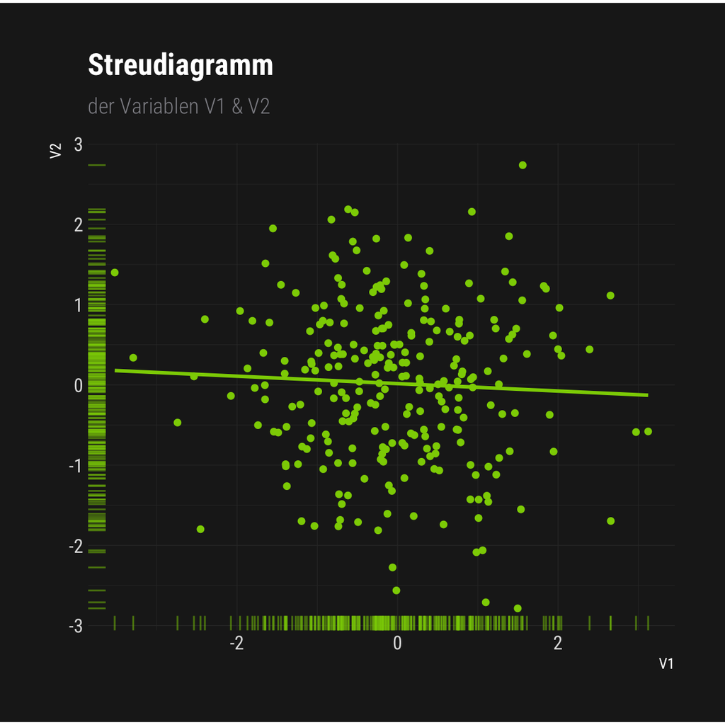

Obige Abbildung zeigt die Assoziation der beiden Variablen V1 und V2. Welches Pearson’s r(V1,V2) passt am besten zu diesen Daten?

-0.75-0.4-0.050.30.651

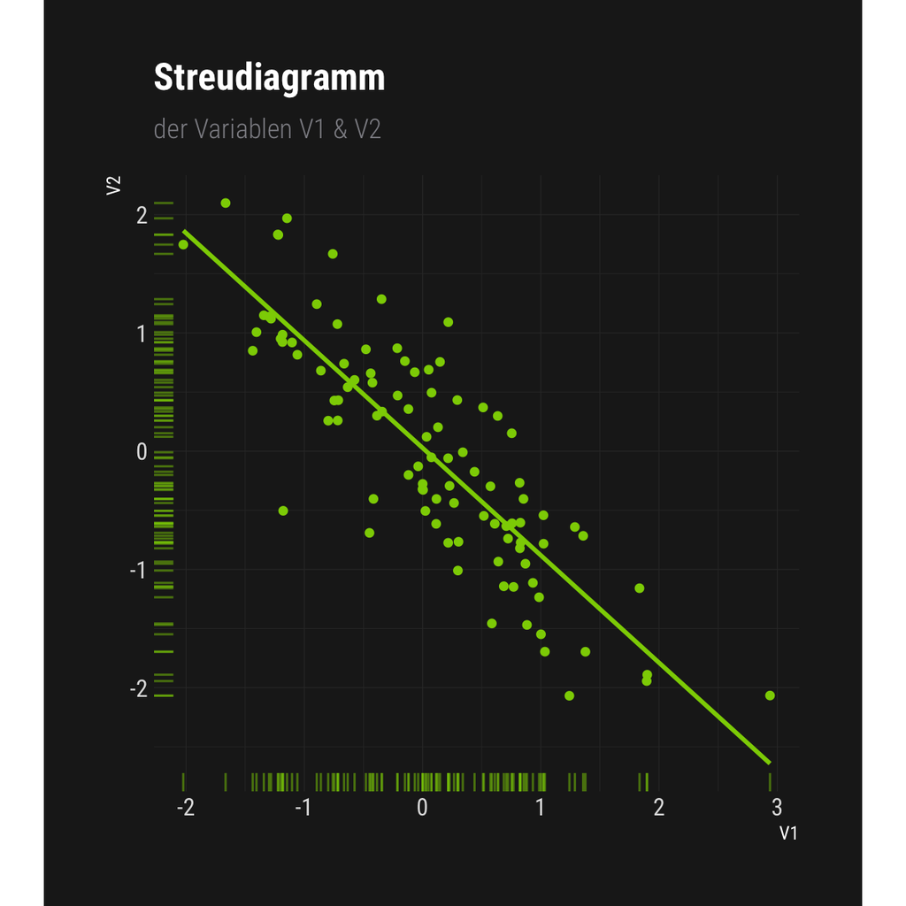

Obige Abbildung zeigt die Assoziation der beiden Variablen V1 und V2. Welches Pearson’s r(V1,V2) passt am besten zu diesen Daten?

-0.85-0.5-0.150.20.550.9

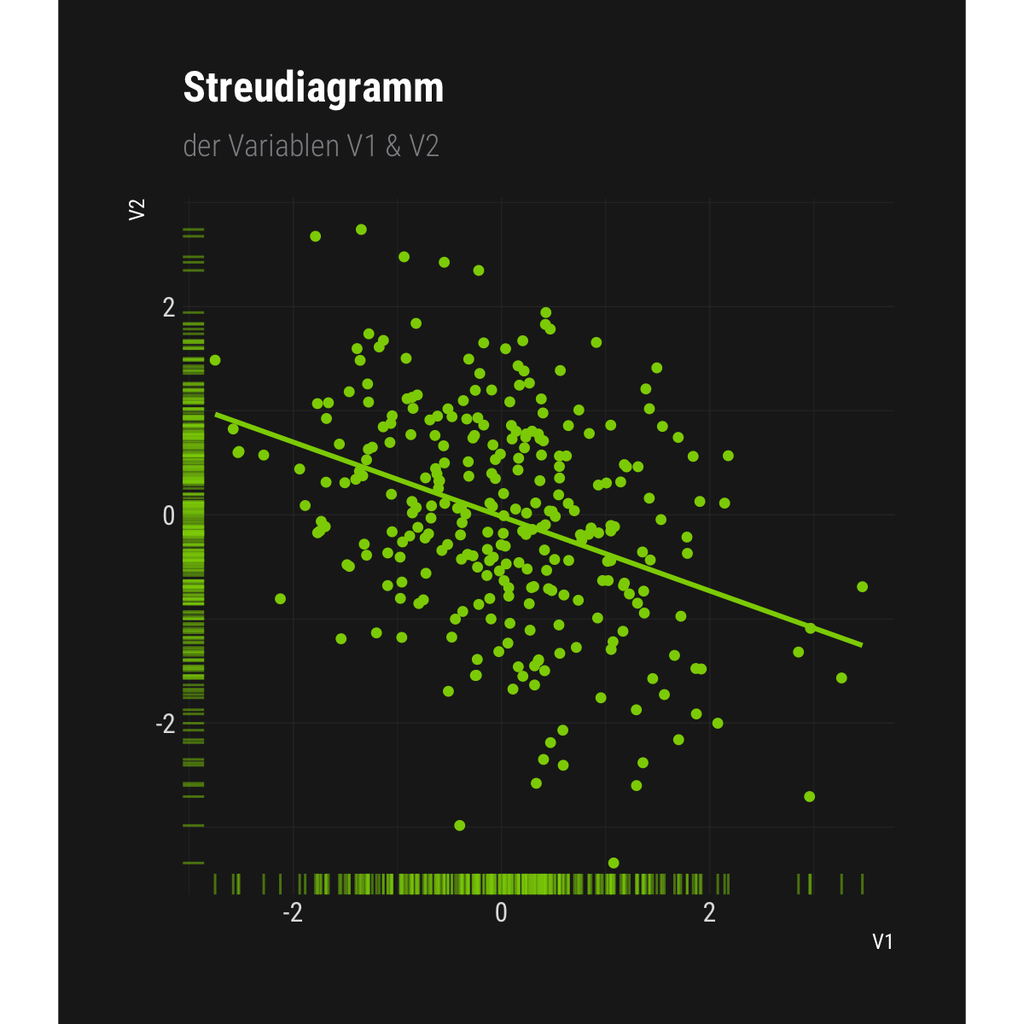

Obige Abbildung zeigt die Assoziation der beiden Variablen V1 und V2. Welches Pearson’s r(V1,V2) passt am besten zu diesen Daten?

-0.71-0.36-0.010.340.69

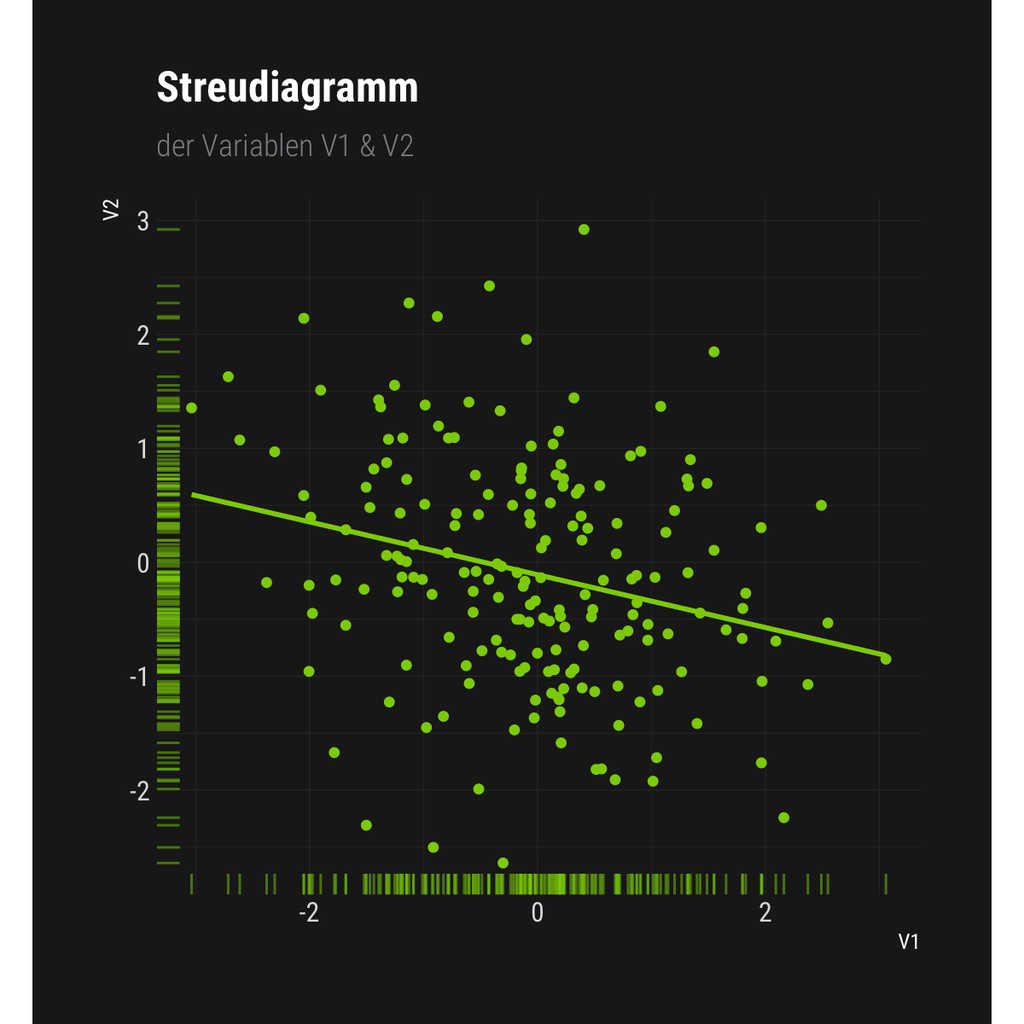

Obige Abbildung zeigt die Assoziation der beiden Variablen V1 und V2. Welches Pearson’s r(V1,V2) passt am besten zu diesen Daten?

-0.96-0.61-0.260.090.440.79

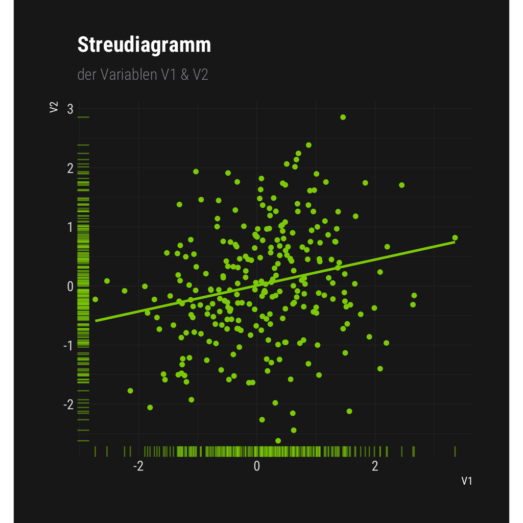

Obige Abbildung zeigt die Assoziation der beiden Variablen V1 und V2. Welches Pearson’s r(V1,V2) passt am besten zu diesen Daten?

-0.83-0.48-0.130.220.570.92